# WS 26: Bayesian Inference Pt. 2

## Steps for Bayesian Inference

- Write down the prior probabilities
- Calculate likelihoods for each model using a tree diagram
- find the posterior probabilities
  - Multiply prior probabilities and likelihoods for each model (this is the numerator for each fraction)
  - Add together everything in the last step (this is the denominator for every fraction)
  - divide each number from two steps ago (the numerators) by the number from the last step (the denominator)
- interpret your results and find the Bayes factor.

## Effectiveness of a new treatment

### An Example

- A study will be performed for a new medication.
- Three doctors have very different opinions about how effective.
- Dr. A is open minded about the effectiveness, it could be effective or not with equal probability.
- Dr. B is more optimistic about the medication and thinks it will be fairly effective.
- Dr. C refuses to believe that the medication does anything at all.

We will measure the proportion of people in the study that feel better:

- $p > .5$ means the medication is effective
- $p=.5$ means the medication has no effect
- $p < .5$ means the medication is detrimental

Here are the prior distributions for each doctor:

### Dr. A

| p | $0$ | $.1$ | $.2$ | $.3$ | $.4$ | $.5$ | $.6$ | $.7$ | $.8$ | $.9$ | $1$ |
| --- | --- | --- | --- | --- | --- | --- | --- | --- | --- | --- | --- |
| prob. | $1/11$ | $1/11$ | $1/11$ | $1/11$ | $1/11$ | $1/11$ | $1/11$ | $1/11$ | $1/11$ | $1/11$ | $1/11$ |

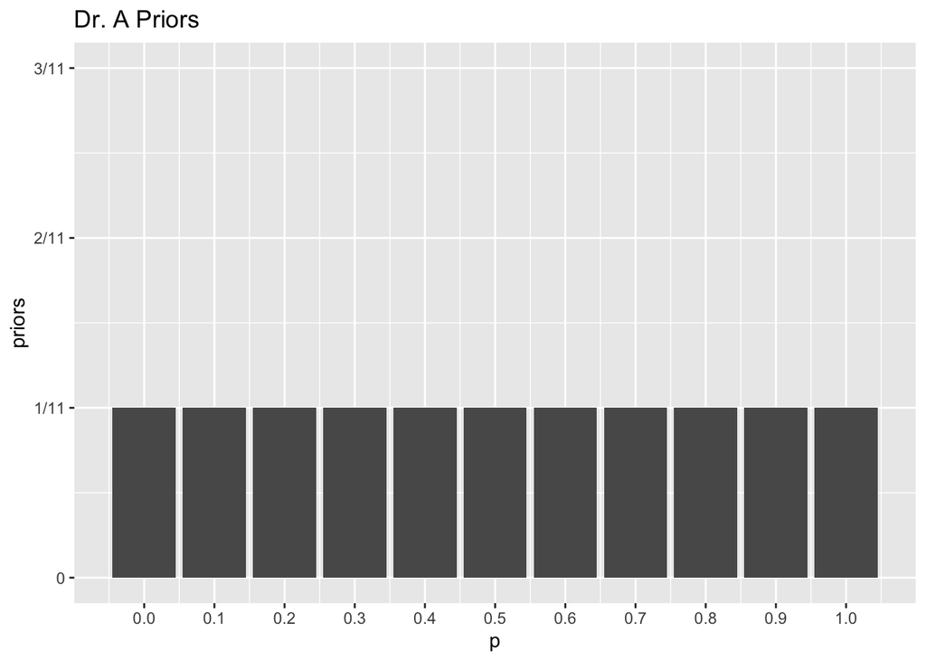

```r
# Dr. A priors
p <- c(0,.1,.2,.3,.4,.5,.6,.7,.8,.9,1)
dr_A <- data.frame( p=p, priors = c(1/11,1/11,1/11,1/11,1/11,1/11,1/11,1/11,1/11,1/11,1/11))

ggplot(dr_A, aes(x = p,y=priors)) +
  geom_col() +
  scale_x_continuous(breaks = seq(0,1, by = .1)) +
  scale_y_continuous(limits = c(0, 3/11), breaks = seq(0, 3/11, by = 1/11), labels=c("0","1/11","2/11","3/11")) +
  labs(title = "Dr. A Priors")
```

```r
# chance of medication being beneficial for a patient according to Dr. A's priors
```

### Dr. B

| p | $0$ | $.1$ | $.2$ | $.3$ | $.4$ | $.5$ | $.6$ | $.7$ | $.8$ | $.9$ | $1$ |
| --- | --- | --- | --- | --- | --- | --- | --- | --- | --- | --- | --- |
| prob. | $0$ | $1/55$ | $2/55$ | $3/55$ | $4/55$ | $5/55$ | $6/55$ | $7/55$ | $8/55$ | $9/55$ | $10/55$ |

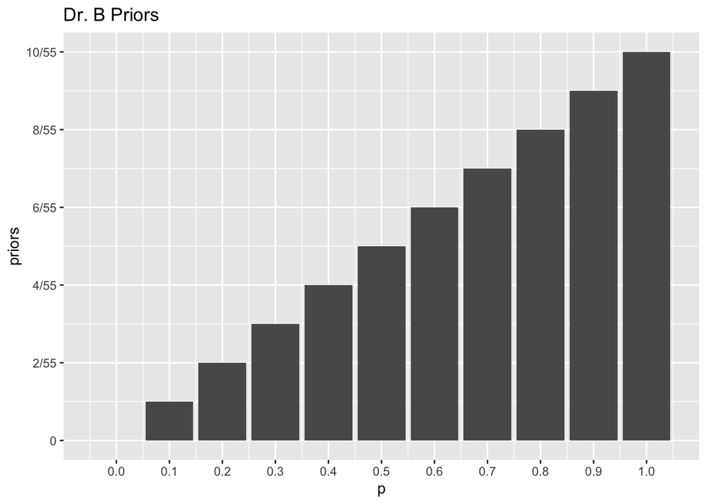

```r
# Dr. B priors
dr_B <- data.frame( p=p, priors = c(0,1/55,2/55,3/55,4/55,5/55,6/55,7/55,8/55,9/55,10/55))

ggplot(dr_B, aes(x = p,y=priors)) +
  geom_col() +
  scale_x_continuous(breaks = seq(0,1, by = .1)) +
  scale_y_continuous(limits = c(0, 10/55), breaks = seq(0, 10/55, by = 2/55), labels=c("0","2/55","4/55","6/55","8/55","10/55")) +
  labs(title = "Dr. B Priors")
```

```r
# chance of medication being beneficial for a patient according to Dr. B's priors
```

### Dr. C

| p | $.5$ |
| --- | --- |
| prob. | $1$ |

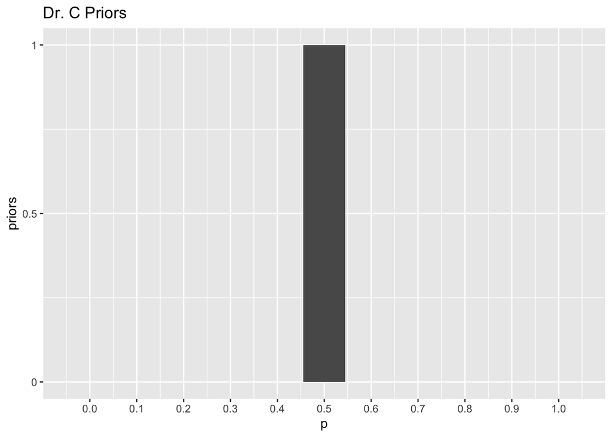

```r
# Dr. A priors
dr_C <- data.frame( p=p, priors = c(0,0,0,0,0,1,0,0,0,0,0))

ggplot(dr_C, aes(x = p,y=priors)) +
  geom_col() +
  scale_x_continuous(breaks = seq(0,1, by = .1)) +
  scale_y_continuous(limits = c(0, 1), breaks = seq(0, 1, by = .5), labels=c("0","0.5","1")) +
  labs(title = "Dr. C Priors")
```

```r
# chance of medication being beneficial for a patient according to Dr. C's priors
```

## Data

- 21 people are studied, and it is recorded if they feel better or worse, the results are given below
- B W B B B B B B B B W B B B B B W B B B B
- $18/21$ of people feel better

## Likelihoods

```r
# the likelihood of this data depends on what model is correct

l_0 <- 1 * 0 * 0 * 0 * 0 * 0 * 0 * 1 * 0 * 0
l_1 <- .1 * .9 * .1 * .1 * .1 * .1 * .1 * .1 * .1 * .1 * .9 * .1 * .1 * .1 * .1 * .1 * .9 * .1 * .1 * .1 * .1
l_2 <- .8^3*.2^18
l_3 <- .7^3*.3^18
l_4 <- .6^3*.4^18
l_5 <- .5^3*.5^18
l_6 <- .4^3*.6^18
l_7 <- .3^3*.7^18
l_8 <- .2^3*.8^18
l_9 <- .1^3*.9^18
l_10 <- 0^3*1^18
likelihoods <- c(l_0,l_1,l_2,l_3,l_4,l_5,l_6,l_7,l_8,l_9,l_10)
```

## Posterior Probabilities

```r
# Dr. A
# find numerators by multiplying priors and likelihoods

# Dr. B
# find numerators by multiplying priors and likelihoods

# Dr. C
# find numerators by multiplying priors and likelihoods
```

```r
# Dr. A
# find denominator by adding together previous step

# Dr. B
# find denominator by adding together previous step

# Dr. C
# find denominator by adding together previous step
```

```r
# Dr. A
# find posteriors

# Dr. B
# find posteriors

# Dr. C
# find posteriors
```